# Linear Regression: Model Specification, Comparison, and Interpretation

- Show All Code
- Hide All Code
- View Source

Workplace rating based on handling complaints, learning, and raises

Author

Salome Carrasco

Published

November 6, 2026

Using the built-in R dataset attitude

## 1.2 Load the required packages

```r
#| label: installing packages

install.packages(c(
  "carData", "dplyr", "tidyr", "ggplot2",
  "broom", "performance", "gt"
))
```

## 1.3 Load the dataset

```r
library(carData)
library(dplyr)
library(tidyr)
library(ggplot2)
library(broom)
library(performance)
library(gt)
```

# Data focus

We will be focusing on four variables: rating (outcome), complaints, learning, and raises (predictors). Rating is the overall workplace rating, so a low score would be a poor work environment, while a high score would be an excellent work environment. Complaints are how well the department handles employee complaints. Learning is the opportunity to learn. Raises is how much the pay increases.

```r
# Keep the same complete-case sample for every model
dat <- attitude |>
  select(rating, complaints, learning, raises) |>
  drop_na()

n <- nrow(dat)
```

## 1.4 Explore data

```r
head(dat)
summary(dat)
nrow(dat)
ncol(dat)
```

### First several observations

Type in Console: head(dat)

### Dataset structure

Names of categories and ranges:

- rating (40-85) (40-85)
- complaints (37-90)
- learning (34-75)
- raises (43-88)

Number of rows: 30 ratings recorded (departments) Type of data: double point

Expectations prior to data observation:

- The less a department handles employee complaints the lower the rating. - The more the raises the higher the rating. This may be more logarithmic than a linear relationship.
- The average score will be higher than 60.

### Calculate descriptive statistics

```r
descriptives <- dat |>
  summarise(
    across(
      c(rating, complaints, learning, raises),
      list(mean = mean, sd = sd, min = min, max = max)
    )
  ) |>
  pivot_longer(
    everything(),
    names_to = c("variable", ".value"),
    names_sep = "_"
  )

descriptives |>
  gt() |>
  fmt_number(columns = where(is.numeric), decimals = 2)
```

Descriptive statistics for continuous variables

| variable | mean | sd | min | max |
| --- | --- | --- | --- | --- |
| rating | 64.63 | 12.17 | 40.00 | 85.00 |
| complaints | 66.60 | 13.31 | 37.00 | 90.00 |
| learning | 56.37 | 11.74 | 34.00 | 75.00 |
| raises | 64.63 | 10.40 | 43.00 | 88.00 |

### Histogram of rating

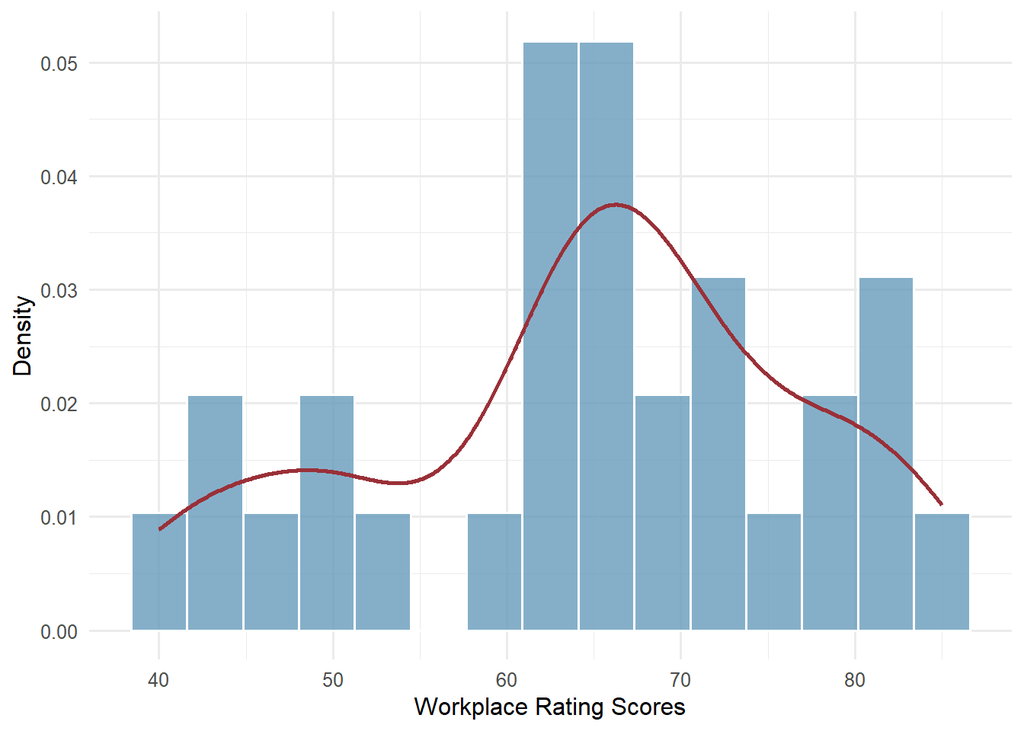

Distribution of workplace rating scores

```r
ggplot(dat, aes(x = rating)) +
  geom_histogram(
    aes(y = after_stat(density)),
    bins = 15,
    fill = "#669BBC",
    color = "white",
    alpha = 0.8
  ) +
  geom_density(
    linewidth = 0.9,
    color = "#9A3038"
  ) +
  labs(
    x = "Workplace Rating Scores",
    y = "Density"
  ) +
  theme_minimal(base_size = 12)
```

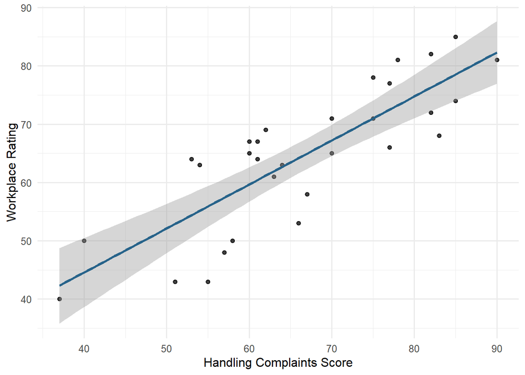

Relationship between how well complaints are handled and rating

```r
ggplot(dat, aes(x = complaints, y = rating)) +
  geom_point(alpha = 0.75) +
  geom_smooth(
    method = "lm",
    se = TRUE,
    color = "#27638A"
  ) +
  labs(
    x = "Handling Complaints Score",
    y = "Workplace Rating"
  ) +
  theme_minimal(base_size = 12)
```

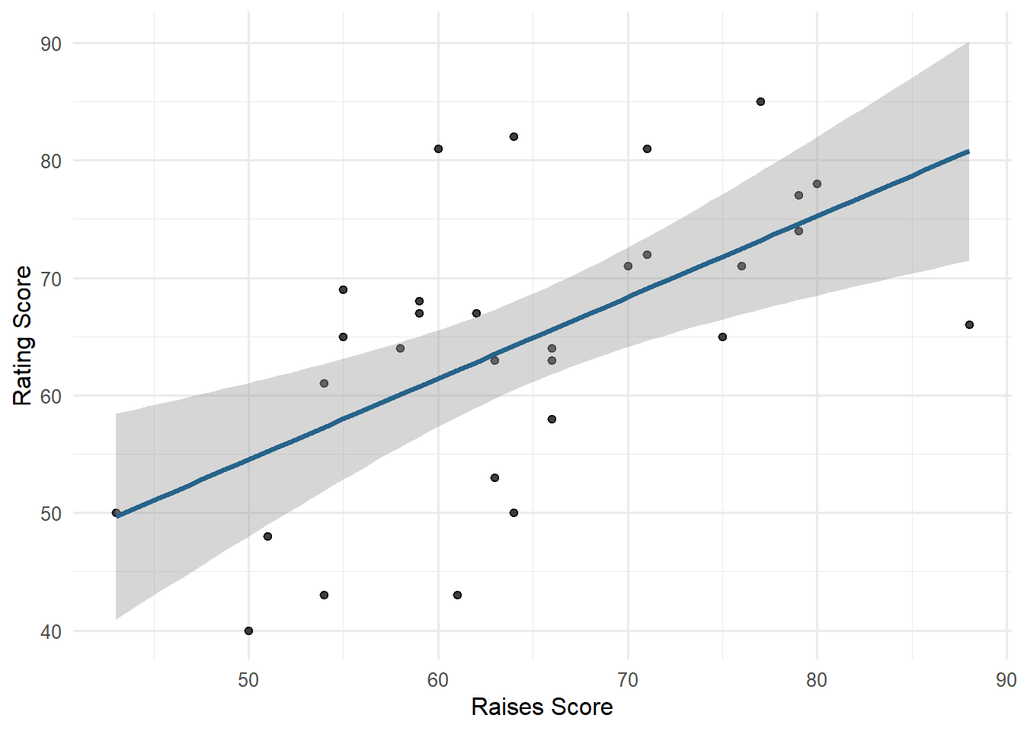

Relationship between raises and rating

```r
ggplot(dat, aes(x = raises, y = rating)) +
  geom_point(alpha = 0.75) +
  geom_smooth(
    method = "lm",
    se = TRUE,
    color = "#27638A"
  ) +
  labs(
    x = "Raises Score",
    y = "Rating Score"
  ) +
  theme_minimal(base_size = 12)
```

## 2.1 Research question and predictions

How are scores of handling complaints, learning oportunities, and raises associated with workplace ratings?

These are predictions about associations, not causal effects.

## 2.2 Specify and estimate competing models

We will fit an intercept-only model and three increasingly complex substantive models.

| Model | Formula | Research rationale |
| --- | --- | --- |
| M0: Null | `rating ~ 1` | Baseline model |
| M1: Complaints | `rating ~ complaints` | Rating varies with complaints |
| M2: Complaints + Learning | `rating ~ complaints + learning` | Learning explains additional variation |
| M3: Expanded | `rating ~ complaints + learning + raises` | Raises explain additional variation |

The models are **nested**: each successive model contains all predictors from the preceding model, plus one or more additional predictors.

```r
# Intercept-only model
mod0 <- lm(rating ~ 1, data = dat)

# Complaints model
mod1 <- lm(rating ~ complaints, data = dat)

# Complaints + learning model
mod2 <- lm(rating ~ complaints + learning, data = dat)

# Expanded model
mod3 <- lm(rating ~ complaints + learning + raises, data = dat)
```

## 2.3 Inspecting the fitted models

Input resuls in **R Console**:

```r
summary(mod0)
summary(mod1)
summary(mod2)
summary(mod3)

confint(mod3)
```

- M0
  - Intercept represents the sample mean rating score
  - Estimated regression coefficient (64.63)
- M1
  - Intercept represents the predicted rating when complaints are zero (14.38)
  - Complaints coefficient represents the association between complaints and rating (0.75)
  - Positive association with complaints (+0.75)
  - Model R² explains 68.13% of variation, adjusted R² explains 66.99% of variation in ratings
- M2
  - Intercept represent the predicted rating complaints and learning are zero (9.87)
  - Complaints coefficient represents the association after adjusting for learning
  - Positive association with complaints (+0.64) and learning (+0.21)
  - Model R² explains 70.8% of variation, adjusted R² explains to 68.6% of variation in ratings
- M3
  - Intercept represents the predicted rating when complaints, learning, and raises are zero (10.52)
  - Complaints coefficient represents the association between complaints and rating after adjusting for learning and raises
  - Positive association with complaints (+0.65) and learning (+0.22), and negative association with raises (−0.03)
  - Model R² explains 70.83% of variation, adjusted R² explains 67.46% of variation in ratings

Overall complaints coefficients decrease slightly but remain positive and statistically significant. Learning remains positive increasing slightly but not significant. Raises has a small negative coefficient but is not statistically significant

## Compare the models

### 3.1 Nested-model F-test

```r
tests <- anova(mod0, mod1, mod2, mod3)

tests
```

```
Analysis of Variance Table

Model 1: rating ~ 1
Model 2: rating ~ complaints
Model 3: rating ~ complaints + learning
Model 4: rating ~ complaints + learning + raises
  Res.Df    RSS Df Sum of Sq       F    Pr(>F)
1     29 4297.0
2     28 1369.4  1   2927.58 60.7256 2.884e-08 ***
3     27 1254.6  1    114.73  2.3799    0.1350
4     26 1253.5  1      1.19  0.0246    0.8765
---
Signif. codes:  0 '***' 0.001 '**' 0.01 '*' 0.05 '.' 0.1 ' ' 1
```

```r
tests <- tests |>
  select(Res.Df, Df, F, `Pr(>F)`) |>
  rename(
    Residual.df = Res.Df,
    Nested.Df = Df,
    Nested.F.stat = F,
    Nested.p.value = `Pr(>F)`
  )
```

### 3.2 Extract model-level performance statistics

```r
glance0 <- glance(mod0)
glance1 <- glance(mod1)
glance2 <- glance(mod2)
glance3 <- glance(mod3)
```

```r
mods <- c(
  "M0: Null",
  "M1: Complaints",
  "M2: + Learning",
  "M3: + Raises"
)

glances <- rbind(
  glance0,
  glance1,
  glance2,
  glance3
)
```

```r
comparison_table <- cbind(
  Model = mods,
  glances,
  tests
)
```

### 3.3 Calculate changes in explained varience (RMSE)

```r
comparison_table <- comparison_table |>
  mutate(
    Delta.R2 = r.squared - lag(r.squared),

    RMSE = c(
      sqrt(mean(residuals(mod0)^2)),
      sqrt(mean(residuals(mod1)^2)),
      sqrt(mean(residuals(mod2)^2)),
      sqrt(mean(residuals(mod3)^2))
    )
  ) |>
  select(
    Model,
    r.squared,
    Delta.R2,
    adj.r.squared,
    RMSE,
    Residual.df,
    Nested.Df,
    Nested.F.stat,
    Nested.p.value
  )
```

### 3.4 Combined model-comparison table

```r
comparison_table |>
  gt() |>
  cols_label(
    Model = "Model",
    r.squared = "R²",
    Delta.R2 = "ΔR²",
    adj.r.squared = "Adjusted R²",
    RMSE = "RMSE",
    Residual.df = "Residual df",
    Nested.Df = "Nested df",
    Nested.F.stat = "Nested F",
    Nested.p.value = "Nested p"
  ) |>
  fmt_number(
    columns = c(
      r.squared,
      Delta.R2,
      adj.r.squared,
      RMSE,
      Nested.F.stat
    ),
    decimals = 3
  ) |>
  fmt(
    columns = Nested.p.value,
    fns = function(x) {
      ifelse(
        is.na(x),
        "—",
        ifelse(x < .001, "< .001", sprintf("%.3f", x))
      )
    }
  ) |>
  sub_missing(
    columns = c(Delta.R2, Nested.Df, Nested.F.stat),
    missing_text = "—"
  )
```

Overall model performance and incremental nested-model comparisons

| Model | R² | ΔR² | Adjusted R² | RMSE | Residual df | Nested df | Nested F | Nested p |
| --- | --- | --- | --- | --- | --- | --- | --- | --- |
| M0: Null | 0.000 | — | 0.000 | 11.968 | 29 | — | — | — |
| M1: Complaints | 0.681 | 0.681 | 0.670 | 6.756 | 28 | 1 | 60.726 | < .001 |
| M2: + Learning | 0.708 | 0.027 | 0.686 | 6.467 | 27 | 1 | 2.380 | 0.135 |
| M3: + Raises | 0.708 | 0.000 | 0.675 | 6.464 | 26 | 1 | 0.025 | 0.876 |

The model with the highest R² (M3) has the largest portion of variation explained at 70.8%. However M2 has a higher adjusted R². The adjusted R² increases with each model, but drops at the last model. These adjusted R² patterns suggest that adding raises doesn’t improve the model as much. M1 with complaints explains +68.1%, M2 with learning explains +2.7%, Raise has no increase in explanation. Adding complaints (M1) significantly improves the model fit (<0.01) while adding learning (M2) and raises (M3) do not significantly improve the model fit. The RMSE decreases from the initial model (M0) 11.97 to 6.76 when adding complaints (M1). This shows improvement in accuracy for prediction. This tells us that complaints are the most significant in explaining variation in ratings.

#### Additional performance comparison

```r
performance_comparison <- compare_performance(
  mod0,
  mod1,
  mod2,
  mod3,
  rank = TRUE
)
```

[output not shown]

```r
selected_row <- comparison_table |>
  slice_max(
    order_by = adj.r.squared,
    n = 1,
    with_ties = FALSE
  )

selected_name <- selected_row$Model

selected_model <- switch(
  selected_name,
  "M0: Null" = mod0,
  "M1: Complaints" = mod1,
  "M2: + Learning" = mod2,
  "M3: + Raises" = mod3
)
```

## 4.1 Examine assumptions

```r
check_model(mod2)
```

[output not shown]

## 4.2 Standard diagnostic plots

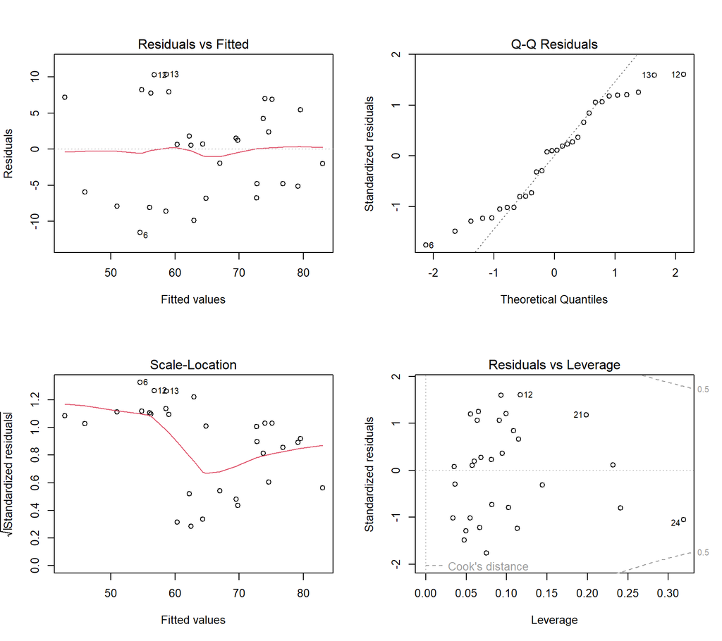

Regression diagnostic plots for the provisionally selected model

```r
op <- par(mfrow = c(2, 2))

plot(selected_model)
```

```r
par(op)
```

The Q-Q plot suggests normality assumption is reasonably satisfied as most points follow the reference line. Interestingly, the points follow a step-like pattern with deviations on both tails. This suggests potential straying from normality in the extreme residuals and at certain degrees along the reference line. The deviations don’t appear substantial to affect confidence in the model, it just seems to show a pattern that there may be a trend of similar average numbers across ratings.

## 5.1 Select a model

Model chosen is the second one where complaints and learning are included when testing workplace ratings.

## 5.2 Create coefficient table

```r
coefficient_results <- tidy(
  selected_model,
  conf.int = TRUE,
  conf.level = 0.95
)
```

### Create a formatted coefficient table

```r
coefficient_results |>
  select(
    term,
    estimate,
    std.error,
    conf.low,
    conf.high,
    p.value
  ) |>
  gt() |>
  cols_label(
    term = "Predictor",
    estimate = "Estimate",
    std.error = "SE",
    conf.low = "95% CI lower",
    conf.high = "95% CI upper",
    p.value = "p"
  ) |>
  fmt_number(
    columns = c(
      estimate,
      std.error,
      conf.low,
      conf.high
    ),
    decimals = 3
  ) |>
  fmt(
    columns = p.value,
    fns = function(x) {
      ifelse(
        x < .001,
        "< .001",
        sprintf("%.3f", x)
      )
    }
  )
```

Unstandardized regression coefficients for the selected model

| Predictor | Estimate | SE | 95% CI lower | 95% CI upper | p |
| --- | --- | --- | --- | --- | --- |
| (Intercept) | 9.871 | 7.061 | −4.618 | 24.359 | 0.174 |
| complaints | 0.644 | 0.118 | 0.400 | 0.887 | < .001 |
| learning | 0.211 | 0.134 | −0.065 | 0.487 | 0.128 |

In M2, the intercept represents the predicted rating when complaints and learning are both zero. The estimate is 9.871, with a 95% confidence interval ranging from -4.618 to 24.359. Complaints has a **positive** association with ratings, meaning that for every one-unit increase in complaints, the predicted rating increases by 0.644 points, where learning is held constant. The 95% confidence interval ranges from 0.4 to 0.887, indicating a **statistically significant positive** association. Learning also has a positive association with ratings, with every one-unit increase in learning corresponding to an increase of 0.211 points, holding complaints constant. However, its 95% confidence interval ranges from -0.065 to 0.487, which includes zero, indicating that learning is **not a statistically significant** predictor of ratings.

## 6 Discuss your findings and limitations

These results suggest that when a workplace handles complaints frequently there is overall an increased rating of the workplace. Additionally when including more learning opportunities for workers there is also an increased rating of the workplace. In the last model we found that increasing pay doesn’t significantly impact how workers rate their workplace as much as dealing with complaints and learning opportunities. Overall, the findings suggest that a workplace that with conflict management at it’s core that encourages growth and development leads to a more positive connection with a work environment. However some limitations to consider would be a small sample size with 30 administrations observed which may limit how much we can generalize from these findings. The results show associations rather than causation, meaning we can’t conclude that better complaint handling directly causes higher workplace ratings. With learning and pay not showing to be statistically significant, interpretations of their affect are limited. There are also other workplace factors that can be at play that is outside of what we observed, like a feeling of equity and inclusion, offering time off, like maternity leave, and a feeling of a more male or female dominated work environment.